# Reference Documentation

Thomas Day

2023-02-05

# Basics

## R Projects

It’s a good idea to work within R projects. R projects allow an simple way to group your data and code in one place. To create an R project

1. click `New Project` from the `File` drop down menu
2. Select `New Directory`, unless you have an existing you’d rather use
3. Select `New Project` as the type
4. Choose a name for the new folder and specify the location for it
5. Click `Create Project`

This will create new folder with that name and set your working directory to it. The working directory is where R will search for files. You will also notice it created a .Rpoj file of the same name. This file is a shortcut to open RStudio to that project with appropriate working directory set. Rproject directories will also save your history of executed commands, so you can go look back if your ever need to.

### Session Data

When you run code in the R console, all your data will be saved in the environment. This allows you to access and use previously created variables. It is a good idea to start each session clean. You will notice that when you exit, R will ask if you want to save a workspace image. You should click “no.”

To stop R from restoring old data:

1. Go to the `Tools` drop down menu
2. Click `Global Options`
3. Within the `General` section under the `Basic` tab, uncheck “Restore .RData into workspace at startup”
4. Click `OK` or `Apply` and close the menu

Why?

- To facilitate better code
  - Since you’ll have to rerun it each time, you’ll need to write clean code
- To clear up unused objects to save storage and stop confusion on what’s important
  - Some old objects could introduce bugs

## Variables and Assignment

Variables store information. You can create a variable by assigning a value to it using the assignment operator: `<-`. Using the assignment operator again will overwrite the previous value. You can print a variable using the `print` function, or just having it on a line by itself.

**Tip** Use descriptive names for your variables and avoid using key words or names of functions.

```r
# creating a variable and assigning a string to it
my_variable <- 'my value'
my_variable
```

```
## [1] "my value"
```

```r
# assigning a new value to the variable
my_variable <- 'new value'
my_variable
```

```
## [1] "new value"
```

```r
# creating a variable and assigning a number to it
another_variable <- 123
another_variable
```

```
## [1] 123
```

### Vectors

In R, all basic variables are vectors. The variables we created above were all vectors of length one. We can create longer vectors using the function`c()`

```r
# a vector of length 1
vector <- 'value'
vector
```

```
## [1] "value"
```

```r
# a vector of length 9
my_vector <- c(1, 2, 3, 4, 5, 6, 7, 8, 9)
my_vector
```

```
## [1] 1 2 3 4 5 6 7 8 9
```

```r
# a vector of length 2
another_vector <- c('val1', 'val2')
another_vector
```

```
## [1] "val1" "val2"
```

You can access elements of the vector using square bracket notation `[ ]`. Vectors in R are 1-indexed, meaning the first element is index 1.

```r
# accessing the 3rd element
my_vector[3]
```

```
## [1] 3
```

```r
# assigning a new value to the 8th element
my_vector[8] <- 10

# accessing everything but the 4th element
my_vector[-4]
```

```
## [1]  1  2  3  5  6  7 10  9
```

```r
# accessing the 3rd to 7th element and everything in between
my_vector[3:7]
```

```
## [1] 3 4 5 6 7
```

### Data Types

Values in R each have a type associated with it. Types specify the what kind of information is stored, how it is stored, and what you can do with it. The data types you should be familiar with:

- `numeric` stores number like values: 10, 9.5, -33
  - there are also `int` and `double` types
- `character` stores words, also known as a string: “R”, “programming”
- `logical` stores Boolean data: TRUE, FALSE
- `factor` stores categorical data, also known as enumerated types: “high”, “medium”, “low”

#### Factors

You can convert a variable to a factor by using the command `as.factor()`

```r
var <- c('high', 'med', 'low')
# var is currently of character type
class(var)
```

```
## [1] "character"
```

```r
var <- as.factor(var)
# now it is a factor type
class(var)
```

```
## [1] "factor"
```

```r
var
```

```
## [1] high med  low
## Levels: high low med
```

Sometimes you will have numeric values that would make more sense as factor values. The rule of thumb is to consider if adding two values “makes sense”. For example, you can have a variable called rank with the values 1, 2, and 3. Does rank 1 + rank 2 = rank 3? No, that doesn’t make sense. So this should be a factor. Each number represents a different idea or group.

For characters, it can sometimes be trickier. The rule of thumb is to ask if two string with the same characters are unique. For example, say you have data on a whole bunch of people, including their names. You see two first names are the same. Would all people with the name “Sarah” be the same person or same group? No, each “Sarah” is unique, so this should remain a character type.

Now suppose you have data a bunch of sports teams. Each team has an associated state. Here, the state names are not unique. If you see a baseball team with state “MI” and a football team with state “MI”, the state names are not referencing two unique places. So in this case, it would make sense to convert it to a factor type.

To sum it up, convert anything you think is referring to categories of things into factors and leave things referring to unique data or actual numbers alone.

## Functions

Functions are bits of code that will run when you call them. They usually have parameters and return values. Functions are how you will do most things in R. You call a function by using the name followed by parenthesis. Some parameters are optional and can be specified using their name followed by an equals sign and the parameter value.

```r
# pass the value or object you want to print as the parameter
print("Hello World")
```

```
## [1] "Hello World"
```

```r
# the log function excepts two parameters,
# here we use the name for the second parameter
# it returns a value that we can store
hundred_log_10 <- log(100, base=10)

# we don't have to use the name for the second parameter,
# as long as we place the values in the correct places
# by not storing the value, R will automatically print it
log(100, 10)
```

```
## [1] 2
```

**Tip** It is a good idea to use the parameter names when specifying optional arguments, that way you won’t have to worry about which argument goes where.

**Tip** To learn more about a function, use `?` before the function name, then run it. This will pull up the documentation instead of executing it. Alternative, you can press `F1` when your cursor is within the function name.

```r
# you can leave out the parenthesis and parameters
?log(10)
?log()
?log
```

## R Packages

There are a lot of built in functions in R at our disposal, but sometimes we need more functionality. This is where packages come in. Packages are basically groups of code, functions, and data that can imported and used. Packages are often written by third parties and need to be downloaded and installed before they can be loaded and used. The most common place to get packages is CRAN. To install a package, use `install.packages` and pass a string of the package’s name. Example:

```r
# Install the neuralnet package to get access to many useful neural network functions
install.packages('neuralnet')
```

You only need to install a package once, unless updating, so leave it out of R scripts and Rmd files. Instead, run the `install.packages` command in the console. If you want to automate package installing, for sharing Rmd files and scripts, you can use the following:

```r
if (!require(tidyverse)) {
    install.packages('tidyverse')
    library(tidyverse)
}
```

The `require` function checks to see the the user has the required library installed. If so, it loads the package and returns true. If the the return is false–meaning the package is not installed–we enter the if block. There, we can install the package and then load it as normal.

To update a package, just run `install.packages` again.

**Tip** Notice where strings are used and where they aren’t. `install.packages` uses a string to search CRAN for a matching repository. `library` doesn’t need to use a string, as the ‘name’ or ‘symbol’ is available after installation.

Sometimes different packages have functions with same name. We can specify to R which we are referring to by using a special namespace syntax: `<package name>::<function or data set name>`. Example:

```r
library(nycflights13)
# accessing the flights data set from nycflights13 package and storing a copy to flights_df
flights_df <- nycflights13::flights

# access the median function from the R stats package
stats::median(flights_df$air_time, na.rm = TRUE)
```

```
## [1] 129
```

**Tip** When you load a package, you don’t need to use this syntax unless two functions share the same name and one overwrites the other. You do need to use this syntax for data sets.

# R Markdown

R Markdown is a powerful package that makes your R code presentable. Install it using `install.packages('rmarkdown')`. R Markdown is a type of markdown document. Markdown documents are text documents that have some syntax to make the text more readable. R Markdown also allows the running of R code in your document. This document’s source code is in an Rmd file, the file type of R Markdown. Take a look at it to see some of the tools I used to make this document more navigable and readable. This section will cover some of them and a few more I didn’t use.

## Table of Contents

Having a table of contents is important for larger reports. At the top of your Rmd file, you can replace the output parameter with:

```
output:
  html_document :
   toc : true
   toc_float : true
```

We are saying the the output will be an html document with a table of contents. I also specify that I want my table of contents to follow the user as he or she scrolls the page. You’ll also notice that the table expands and contracts as you scroll. This depth can be controlled with the `toc_depth` parameter, which defaults to 3. You can also give your sections numbers using the `number_sections` parameter.

```
output:
  html_document :
   toc : true
   toc_depth : 4
   number_sections : true
```

When using a table of contents, you’ll want to use headers. Use `#`’s to specify the depth and size of the header.

```
# Header 1

## Subsection

### Nested Subsection

#### Further Nesting

# Header 2
```

## Code Blocks

In R Markdown, put your code in code blocks, called chunks. Code blocks are designated with triple back ticks: ```. Then to specify the language of that block, use `{ }`. In our case, we will use a set up like so:

````
```{r}
<code goes here>
```
````

**TIP** Use `\` to escape a special character in R Markdown.

R will run all your code in the code blocks when knitting and output the results. There are options you can specify to change this behavior, however. Some options to take note of:

- `eval`
  - if **FALSE**, the code won’t run but the code will still appear in the document
- `include`
  - if **FALSE**, the code will run but not appear in the document
- `echo`
  - if **FALSE**, the code will run and the output will show, but the code will not show
- `cache`
  - if **TRUE**, R will cache the results and use the results for future knits instead of rerunning
  - The results will be recalculated if the block is edited
  - Useful for blocks that take a long time to run
- `error`
  - if **FALSE**, R will not output error messages generated by the code
- `message`
  - if **FALSE**, R will not output any messages generated by the code
- `warning`
  - if **FALSE**, R will not output warning messages generated by the code

You can also give you code blocks descriptive names to help find bugs when knitting or for jumping to code. Specify the name after `r` but before the options. Your code block could look something like this:

````
```{r my_chunk, cache=TRUE, error=FALSE, warning=FALSE}
<code goes here>
```
````

### Inline Code Blocks

You can also run tiny bits of code within your write ups. This is useful when talking about a result. Use single back ticks for this followed by an r: ``r` `<your code>` `. You can use a variable name to get its value or run a function.

## Other Useful Syntax

Use `*` or `_` for italics: *word* -> *word*

Use `**` or `__` for bold: **word** -> **word**

Set text for a link using `[<text>](<link>)`: [R Markdown Cheat Sheet](https://www.rstudio.com/wp-content/uploads/2015/03/rmarkdown-reference.pdf)

Show an image using `![](<file path or link to image>)`:

[figure not shown]

Check the R Markdown [documentation](https://rmarkdown.rstudio.com/articles.html) or this [book](https://bookdown.org/yihui/rmarkdown/) for more R Markdown tips and tricks.

# Data and Data Frames

## Reading in Data

Most data you will use in this class will come from csv files. You will read this data into a data frame using the `read.csv` function. Alternatively, you can get data from packages, as shown above.

```r
# reading from a csv
flights <- read.csv('nycflightsjan13.csv')

# copying from a package
flights_from_package <- nycflights13::flights
```

In either case, we store the result in a variable. The result is a data frame, which is like a table.

**Tip** Give all your variables descriptive names.

## Data Frames

Data frames are R’s representation a tabular data. It consists of multiple columns, each being a vector. Each column can be a different type. Each row in a data frame represents one entry.

We can explore a data frame using `str` and `summary`. `str` provides the structure of the data frame. It gives the size of the table (number of rows and number of columns), name of each column, the type of each column, and the first several entries in each column.

```r
str(flights)
```

```
## 'data.frame':    27004 obs. of  17 variables:
##  $ X        : int  1 2 3 4 5 6 7 8 9 10 ...
##  $ year     : int  2013 2013 2013 2013 2013 2013 2013 2013 2013 2013 ...
##  $ month    : int  1 1 1 1 1 1 1 1 1 1 ...
##  $ day      : int  1 1 1 1 1 1 1 1 1 1 ...
##  $ dep_time : int  517 533 542 544 554 554 555 557 557 558 ...
##  $ dep_delay: int  2 4 2 -1 -6 -4 -5 -3 -3 -2 ...
##  $ arr_time : int  830 850 923 1004 812 740 913 709 838 753 ...
##  $ arr_delay: int  11 20 33 -18 -25 12 19 -14 -8 8 ...
##  $ carrier  : chr  "UA" "UA" "AA" "B6" ...
##  $ tailnum  : chr  "N14228" "N24211" "N619AA" "N804JB" ...
##  $ flight   : int  1545 1714 1141 725 461 1696 507 5708 79 301 ...
##  $ origin   : chr  "EWR" "LGA" "JFK" "JFK" ...
##  $ dest     : chr  "IAH" "IAH" "MIA" "BQN" ...
##  $ air_time : int  227 227 160 183 116 150 158 53 140 138 ...
##  $ distance : int  1400 1416 1089 1576 762 719 1065 229 944 733 ...
##  $ hour     : int  5 5 5 5 5 5 5 5 5 5 ...
##  $ minute   : int  17 33 42 44 54 54 55 57 57 58 ...
```

In this example, we see that the table consists of 27004 rows and 17 columns. Looking at the columns, we can see `air_time` is an int type and `carrier` is a chr type.

We can also use `nrow` and `ncol` to get the number of rows and columns, respectively.

```r
nrow(flights)
```

```
## [1] 27004
```

```r
ncol(flights)
```

```
## [1] 17
```

`summary` Calculates some basic statistics of each column.

```r
summary(flights)
```

```
##        X              year          month        day           dep_time
##  Min.   :    1   Min.   :2013   Min.   :1   Min.   : 1.00   Min.   :   1
##  1st Qu.: 6752   1st Qu.:2013   1st Qu.:1   1st Qu.: 8.00   1st Qu.: 907
##  Median :13502   Median :2013   Median :1   Median :16.00   Median :1409
##  Mean   :13502   Mean   :2013   Mean   :1   Mean   :15.99   Mean   :1347
##  3rd Qu.:20253   3rd Qu.:2013   3rd Qu.:1   3rd Qu.:24.00   3rd Qu.:1738
##  Max.   :27004   Max.   :2013   Max.   :1   Max.   :31.00   Max.   :2359
##                                                             NA's   :521
##    dep_delay          arr_time      arr_delay         carrier
##  Min.   : -30.00   Min.   :   1   Min.   : -70.00   Length:27004
##  1st Qu.:  -5.00   1st Qu.:1118   1st Qu.: -15.00   Class :character
##  Median :  -2.00   Median :1556   Median :  -3.00   Mode  :character
##  Mean   :  10.04   Mean   :1523   Mean   :   6.13
##  3rd Qu.:   8.00   3rd Qu.:1946   3rd Qu.:  13.00
##  Max.   :1301.00   Max.   :2400   Max.   :1272.00
##  NA's   :521       NA's   :536    NA's   :606
##    tailnum              flight        origin              dest
##  Length:27004       Min.   :   1   Length:27004       Length:27004
##  Class :character   1st Qu.: 542   Class :character   Class :character
##  Mode  :character   Median :1459   Mode  :character   Mode  :character
##                     Mean   :1959
##                     3rd Qu.:3750
##                     Max.   :8500
##
##     air_time        distance         hour           minute
##  Min.   : 20.0   Min.   :  80   Min.   : 0.00   Min.   : 0.00
##  1st Qu.: 84.0   1st Qu.: 483   1st Qu.: 9.00   1st Qu.:16.00
##  Median :137.0   Median : 872   Median :14.00   Median :31.00
##  Mean   :154.2   Mean   :1007   Mean   :13.15   Mean   :31.72
##  3rd Qu.:194.0   3rd Qu.:1372   3rd Qu.:17.00   3rd Qu.:50.00
##  Max.   :667.0   Max.   :4983   Max.   :23.00   Max.   :59.00
##  NA's   :606                    NA's   :521     NA's   :521
```

For numeric data, we will get the min, max, median, mean, 1st and 3rd quartiles, and number of missing data if applicable. For the character data, we don’t get very useful information. For factors, we’ll get the number of entries in each level.

### Accessing Columns and Rows

There are several ways to access a particular column of a data frame. The first is using square bracket notation `[ ]` with the column name as a string: `df["<column name>"]`. You can also use square bracket notation with a column index instead: `df[<index as an int>]`. This will grab the column at that place. The final way to access columns, and the most used, is using the `$` operator followed by the column name: `df$<column name>`. Note, this method doesn’t use strings. This way is particularly useful, as it allows RStudio to autocomplete.

```r
# using column name as a string and square brackets
flights['carrier']
```

```
##    carrier
## 1       UA
## 2       UA
## 3       AA
## 4       B6
## 5       DL
## 6       UA
## 7       B6
## 8       EV
## 9       B6
## 10      AA
##  [ reached 'max' / getOption("max.print") -- omitted 26994 rows ]
```

```r
# using index and square brackets
flights[10]
```

```
##    tailnum
## 1   N14228
## 2   N24211
## 3   N619AA
## 4   N804JB
## 5   N668DN
## 6   N39463
## 7   N516JB
## 8   N829AS
## 9   N593JB
## 10  N3ALAA
##  [ reached 'max' / getOption("max.print") -- omitted 26994 rows ]
```

```r
# using $ and column name
flights$carrier
```

```
##  [1] "UA" "UA" "AA" "B6" "DL" "UA" "B6" "EV" "B6" "AA"
##  [ reached getOption("max.print") -- omitted 26994 entries ]
```

Note that `[ ]` notation returns the column as a n x 1 table. `$` notation will return the column as a vector.

You can access rows using a slight variation on square bracket notation. List the row index and then a trailing column. The trailing comma is needed to differentiate between column idexing and row indexing. `df[<row index>, ]`

```r
# retrieving the 98th entry
flights[98, ]
```

```
##     X year month day dep_time dep_delay arr_time arr_delay carrier tailnum
## 98 98 2013     1   1      752        -3     1041       -18      DL  N325US
##    flight origin dest air_time distance hour minute
## 98   2263    LGA  MCO      140      950    7     52
```

You can also select multiple rows or columns, either using a list or range. You create a list using the `c` function. You can specify a range like so: `<starting range>:<ending range>`, just like we did with vectors. And just like vectors, you can omit indices using `-`.

```r
# selecting several columns by name
flights[c('carrier', 'dep_delay', 'arr_delay')]
```

```
##    carrier dep_delay arr_delay
## 1       UA         2        11
## 2       UA         4        20
## 3       AA         2        33
## 4       B6        -1       -18
## 5       DL        -6       -25
## 6       UA        -4        12
## 7       B6        -5        19
## 8       EV        -3       -14
## 9       B6        -3        -8
## 10      AA        -2         8
## 11      B6        -2        -2
## 12      B6        -2        -3
## 13      UA        -2         7
## 14      UA        -2       -14
## 15      AA        -1        31
## 16      B6         0        -4
##  [ reached 'max' / getOption("max.print") -- omitted 26988 rows ]
```

```r
# selecting several columns by index
flights[c(6, 3, 5)]
```

```
##    dep_delay month dep_time
## 1          2     1      517
## 2          4     1      533
## 3          2     1      542
## 4         -1     1      544
## 5         -6     1      554
## 6         -4     1      554
## 7         -5     1      555
## 8         -3     1      557
## 9         -3     1      557
## 10        -2     1      558
## 11        -2     1      558
## 12        -2     1      558
## 13        -2     1      558
## 14        -2     1      558
## 15        -1     1      559
## 16         0     1      559
##  [ reached 'max' / getOption("max.print") -- omitted 26988 rows ]
```

```r
# selecting a range of columns
flights[2:6]
```

```
##    year month day dep_time dep_delay
## 1  2013     1   1      517         2
## 2  2013     1   1      533         4
## 3  2013     1   1      542         2
## 4  2013     1   1      544        -1
## 5  2013     1   1      554        -6
## 6  2013     1   1      554        -4
## 7  2013     1   1      555        -5
## 8  2013     1   1      557        -3
## 9  2013     1   1      557        -3
## 10 2013     1   1      558        -2
##  [ reached 'max' / getOption("max.print") -- omitted 26994 rows ]
```

```r
# omitting a range of columns
flights[-(1:10)]
```

```
##   flight origin dest air_time distance hour minute
## 1   1545    EWR  IAH      227     1400    5     17
## 2   1714    LGA  IAH      227     1416    5     33
## 3   1141    JFK  MIA      160     1089    5     42
## 4    725    JFK  BQN      183     1576    5     44
## 5    461    LGA  ATL      116      762    5     54
## 6   1696    EWR  ORD      150      719    5     54
## 7    507    EWR  FLL      158     1065    5     55
##  [ reached 'max' / getOption("max.print") -- omitted 26997 rows ]
```

```r
# selecting a set of rows
flights[c(1, 2, 3, 4), ]
```

```
##   X year month day dep_time dep_delay arr_time arr_delay carrier tailnum flight
## 1 1 2013     1   1      517         2      830        11      UA  N14228   1545
## 2 2 2013     1   1      533         4      850        20      UA  N24211   1714
##   origin dest air_time distance hour minute
## 1    EWR  IAH      227     1400    5     17
## 2    LGA  IAH      227     1416    5     33
##  [ reached 'max' / getOption("max.print") -- omitted 2 rows ]
```

```r
# selecting a range of rows
flights[10:20, ]
```

```
##     X year month day dep_time dep_delay arr_time arr_delay carrier tailnum
## 10 10 2013     1   1      558        -2      753         8      AA  N3ALAA
## 11 11 2013     1   1      558        -2      849        -2      B6  N793JB
##    flight origin dest air_time distance hour minute
## 10    301    LGA  ORD      138      733    5     58
## 11     49    JFK  PBI      149     1028    5     58
##  [ reached 'max' / getOption("max.print") -- omitted 9 rows ]
```

One more useful indexing tool is 2D indexing. You can specify both columns and rows using square bracket notation: `df[<rows>, <columns>]`. Or you can a combination of `[ ]` and `$`: `df[<rows>, ]$<column name>` or `df$<column name>[<rows>]`. Note that in the second way, don’t use a comma because you are selecting rows from a 1D vector after using the `$` operator.

```r
# using a range of rows and a list of columns
flights[1:15, c('origin', 'dep_delay')]
```

```
##    origin dep_delay
## 1     EWR         2
## 2     LGA         4
## 3     JFK         2
## 4     JFK        -1
## 5     LGA        -6
## 6     EWR        -4
## 7     EWR        -5
## 8     LGA        -3
## 9     JFK        -3
## 10    LGA        -2
## 11    JFK        -2
## 12    JFK        -2
## 13    JFK        -2
## 14    EWR        -2
## 15    LGA        -1
```

```r
# selecting a range of rows from a given column
flights$distance[1:15]
```

```
##  [1] 1400 1416 1089 1576  762  719 1065  229  944  733 1028 1005 2475 2565 1389
```

```r
# selecting column, after selecting a range of rows
flights[1:15, ]$distance
```

```
##  [1] 1400 1416 1089 1576  762  719 1065  229  944  733 1028 1005 2475 2565 1389
```

## Cleaning

### Deleting Columns

Sometimes, a data set will have columns that have no use to us. One example is a row identifying column, like an index. Identifiers are useful when linking tables together, but once we have all our data, we can just use R row indexing. So we should remove those columns. The `X` column is one example; let’s remove it.

Other columns that should be deleted are columns that provide no interesting information. In the our NYC flights data set, all the flights are from the year 2013 and the month of January, so we don’t need to keep the year column nor month column.

Sometimes you might get duplicate data or create new columns based of old ones that better represent the information you need. There could be many reasons to remove a column.

You delete a column by assigning `NULL` to it: `df$col <- NULL`. Let’s get rid of those uneeded columns.

```r
flights$X <- NULL
flights$year <- NULL
flights$month <- NULL
```

### Changing Types

R infers types when reading in data through a pretty simple process. This means anything that looks like a integer will be saved as an integer type, if it has decimals save it as numeric, and if its not either of those then save it as a character type.

We talked above about factors vs numerica and character types. To reemphasize the rule of thumb for numeric types:

> Does adding make sense?

And the rule for character types:

> Is each value unique or represent a group/category?

Let’s first look at some of the character type columns. `tailnum` is an identifier for aircraft. If we see two flights with the same tail number, that means they were the same plane. Equal tail numbers are not representing unique things, so that should be grouped. So, this column should be transformed to a factor. Similarly, `carrier`, `origin`, and `dest` are representing groups a possibilities; they should all be factors.

What about some of the numeric types? Let’s start with `flight`. Flight numbers are codes used by airlines to identify routes and flights. Would it make sense to add two flight numbers together? No, so therefore they should not stay as number. What about for day of the month? Does it make sense to add two dates together? Typically, no. So `day` would work better as a factor. `hour` and `minute` have similar arguments, but some numeric operations could be useful. For example, we may want the average hour of departure or earliest departure. Sometimes there is not a hard and fast rule for variable types; it depends on what you want to do with your data. We’ll convert those columns to factors because we still have `dep_time` and `arr_time` for arithmetic operations.

To change a column to a factor type, use the `as.factor` command on the column and reassign the output to the same column. Let’s edit our data:

```r
# using flights$tailnum as the parameter
# assigning the output to flights$tailnum
flights$tailnum <- as.factor(flights$tailnum)
flights$carrier <- as.factor(flights$carrier)
flights$origin <- as.factor(flights$origin)
flights$dest <- as.factor(flights$dest)

flights$flight <- as.factor(flights$flight)
flights$day <- as.factor(flights$day)
flights$hour <- as.factor(flights$hour)
flights$minute <- as.factor(flights$minute)
```

Let’s look at the structure and summary of our data again after our cleaning.

```r
str(flights)
```

```
## 'data.frame':    27004 obs. of  14 variables:
##  $ day      : Factor w/ 31 levels "1","2","3","4",..: 1 1 1 1 1 1 1 1 1 1 ...
##  $ dep_time : int  517 533 542 544 554 554 555 557 557 558 ...
##  $ dep_delay: int  2 4 2 -1 -6 -4 -5 -3 -3 -2 ...
##  $ arr_time : int  830 850 923 1004 812 740 913 709 838 753 ...
##  $ arr_delay: int  11 20 33 -18 -25 12 19 -14 -8 8 ...
##  $ carrier  : Factor w/ 16 levels "9E","AA","AS",..: 12 12 2 4 5 12 4 6 4 2 ...
##  $ tailnum  : Factor w/ 3149 levels "","N0EGMQ","N10156",..: 170 448 1968 2544 2147 933 1524 2605 1816 960 ...
##  $ flight   : Factor w/ 1652 levels "1","2","3","4",..: 827 931 633 436 270 918 297 1640 57 155 ...
##  $ origin   : Factor w/ 3 levels "EWR","JFK","LGA": 1 3 2 2 3 1 1 3 2 3 ...
##  $ dest     : Factor w/ 94 levels "ALB","ATL","AUS",..: 39 39 51 9 2 61 31 38 47 61 ...
##  $ air_time : int  227 227 160 183 116 150 158 53 140 138 ...
##  $ distance : int  1400 1416 1089 1576 762 719 1065 229 944 733 ...
##  $ hour     : Factor w/ 23 levels "0","1","2","4",..: 5 5 5 5 5 5 5 5 5 5 ...
##  $ minute   : Factor w/ 60 levels "0","1","2","3",..: 18 34 43 45 55 55 56 58 58 59 ...
```

```r
summary(flights)
```

```
##       day           dep_time      dep_delay          arr_time
##  2      :  943   Min.   :   1   Min.   : -30.00   Min.   :   1
##  7      :  933   1st Qu.: 907   1st Qu.:  -5.00   1st Qu.:1118
##  10     :  932   Median :1409   Median :  -2.00   Median :1556
##  11     :  930   Mean   :1347   Mean   :  10.04   Mean   :1523
##  14     :  928   3rd Qu.:1738   3rd Qu.:   8.00   3rd Qu.:1946
##  31     :  928   Max.   :2359   Max.   :1301.00   Max.   :2400
##  (Other):21410   NA's   :521    NA's   :521       NA's   :536
##    arr_delay          carrier        tailnum          flight      origin
##  Min.   : -70.00   UA     :4637          :  155   11     :   93   EWR:9893
##  1st Qu.: -15.00   B6     :4427   N730MQ :   74   181    :   89   JFK:9161
##  Median :  -3.00   EV     :4171   N739MQ :   73   695    :   82   LGA:7950
##  Mean   :   6.13   DL     :3690   N713MQ :   70   145    :   79
##  3rd Qu.:  13.00   AA     :2794   N719MQ :   66   717    :   76
##  Max.   :1272.00   MQ     :2271   N734MQ :   66   161    :   74
##  NA's   :606       (Other):5014   (Other):26500   (Other):26511
##       dest          air_time        distance         hour           minute
##  ATL    : 1396   Min.   : 20.0   Min.   :  80   8      : 2314   55     :  839
##  ORD    : 1269   1st Qu.: 84.0   1st Qu.: 483   15     : 1968   56     :  775
##  BOS    : 1245   Median :137.0   Median : 872   16     : 1900   54     :  765
##  MCO    : 1175   Mean   :154.2   Mean   :1007   17     : 1863   58     :  735
##  FLL    : 1161   3rd Qu.:194.0   3rd Qu.:1372   18     : 1831   57     :  706
##  LAX    : 1159   Max.   :667.0   Max.   :4983   (Other):16607   (Other):22663
##  (Other):19599   NA's   :606                    NA's   :  521   NA's   :  521
```

We now can see that some of columns give better information than before. We can see how many carriers there are and how many flights each airport receives.

### NA’s, NaN, and NULL

`NA` and `NULL` are two special data types in R. `NA` stands for “not available”. We will see this value when ever a row is missing a value in a column. From above, we see that there are 606 missing values in `air_time`.

`NULL` represents nothing. Null is the value of no value or non-existence. Be careful though, because while it has a similar concept as zero, zero is a value. Zero represent a count of nothing–or false in Boolean values–while null is no value. In other words, zero is measurable while null is not.

`NULL` and `NA` have similar ideas: there is no value. However, their purposes and meanings are different. `NA` represents the idea of a missing value where there should be one. `NULL` is used where there is no value (i.e., no value exists) and `NA` is used where there should be a value (i.e., a value exists but it is unknown). `NULL` is also a special keyword representing the null object. We used this when deleting columns. We are saying to R, give this column no value; in other words, delete it.

`NaN` is yet another special value, but only for numeric types. It stands for “Not a Number”. It comes up most often when a mathematical formula/algorithm is undefined with certain input. $0/0$ is an undefined equation, so will return `NaN`. Other times, NaN is not useful to statisticians, and the concept of infinity would be better. R also has a special value for this `Inf`. $11/0$ will return `Inf`. `NaN` and `Inf` are numerical types and play with functions in different ways, so be wary of them.

```r
0/0
```

```
## [1] NaN
```

```r
11/0
```

```
## [1] Inf
```

```r
# double is a numeric type
typeof(Inf)
```

```
## [1] "double"
```

```r
typeof(NaN)
```

```
## [1] "double"
```

```r
max(NaN, Inf)
```

```
## [1] NaN
```

```r
min(NaN, Inf)
```

```
## [1] NaN
```

```r
max(-3, 6, Inf)
```

```
## [1] Inf
```

```r
min(-3, 6, Inf)
```

```
## [1] -3
```

```r
max(-3, 6, NaN)
```

```
## [1] NaN
```

```r
min(-3, 6, NaN)
```

```
## [1] NaN
```

`NA` has a similar affect to `NaN` when doing arithmetic. All return values will be `NA`, since R has no way of knowing how to add (or subtract or multiply or …) a number and a non-number. So we will need a way of dealing with NA values.

```r
max(flights$arr_delay)
```

```
## [1] NA
```

One way is to tell R to ignore rows with `NA` values for that specific function. Some functions have a parameter similar to `na.rm` which takes a Bolean value and defaults to `FALSE`. If we pass in `TRUE`, R will omit all `NA` values in its calculations.

```r
max(flights$arr_delay, na.rm = TRUE)
```

```
## [1] 1272
```

Similar to this approach is deleting all rows that have NA values.

```r
no_nas <- na.omit(flights)
summary(no_nas)
```

```
##       day           dep_time      dep_delay           arr_time
##  7      :  930   Min.   :   1   Min.   : -30.000   Min.   :   1
##  10     :  929   1st Qu.: 906   1st Qu.:  -5.000   1st Qu.:1118
##  2      :  928   Median :1408   Median :  -2.000   Median :1555
##  14     :  923   Mean   :1347   Mean   :   9.986   Mean   :1523
##  11     :  917   3rd Qu.:1738   3rd Qu.:   8.000   3rd Qu.:1946
##  17     :  915   Max.   :2359   Max.   :1301.000   Max.   :2400
##  (Other):20856
##    arr_delay          carrier        tailnum          flight      origin
##  Min.   : -70.00   UA     :4590   N730MQ :   72   11     :   93   EWR:9616
##  1st Qu.: -15.00   B6     :4413   N739MQ :   70   181    :   88   JFK:9031
##  Median :  -3.00   EV     :3964   N713MQ :   67   695    :   82   LGA:7751
##  Mean   :   6.13   DL     :3655   N725MQ :   65   145    :   77
##  3rd Qu.:  13.00   AA     :2724   N723MQ :   64   161    :   74
##  Max.   :1272.00   MQ     :2203   N734MQ :   64   717    :   74
##                    (Other):4849   (Other):25996   (Other):25910
##       dest          air_time        distance         hour           minute
##  ATL    : 1368   Min.   : 20.0   Min.   :  80   8      : 2311   55     :  835
##  ORD    : 1227   1st Qu.: 84.0   1st Qu.: 488   15     : 1962   56     :  775
##  BOS    : 1214   Median :137.0   Median : 872   16     : 1894   54     :  765
##  MCO    : 1173   Mean   :154.2   Mean   :1014   17     : 1856   58     :  732
##  FLL    : 1155   3rd Qu.:194.0   3rd Qu.:1372   18     : 1826   57     :  705
##  LAX    : 1154   Max.   :667.0   Max.   :4983   6      : 1818   53     :  704
##  (Other):19107                                  (Other):14731   (Other):21882
```

```r
nrow(no_nas)
```

```
## [1] 26398
```

Notice how many rows we lost: 606. That’s a lot of information gone that would’ve been useful. To keep that information, we can modify our data to fill in those missing values. Sometimes we can go through and manually infer or find what those values should be. Other times, it can suffice to replace NAs with the median or mean of your data. Which one you use depends on what you want to do with your data and the distribution of your data.

```r
# calculate the mean (or median) of the column, omitting the NAs
dep_time_mean <- mean(flights$dep_time, na.rm = TRUE)
# use an ifelse statement to reassign the column with the appropriate values
flights$dep_time <- ifelse(is.na(flights$dep_time), # if that value is missing
                           dep_time_mean,           # replace it with the mean
                           flights$dep_time)        # else, keep the data unchanged

# we can also do that in one step
flights$dep_delay <- ifelse(is.na(flights$dep_delay),               # if that value is missing
                           mean(flights$dep_delay, na.rm = TRUE),   # replace it with the mean
                           flights$dep_delay)                       # else, keep the data unchanged

flights$arr_time <- ifelse(is.na(flights$arr_time),
                           mean(flights$arr_time, na.rm = TRUE),
                           flights$arr_time)

flights$arr_delay <- ifelse(is.na(flights$arr_delay),
                           mean(flights$arr_delay, na.rm = TRUE),
                           flights$arr_delay)

flights$air_time <- ifelse(is.na(flights$air_time),
                           mean(flights$air_time, na.rm = TRUE),
                           flights$air_time)
```

Let’s take one last look at our data after cleaning.

```r
str(flights)
```

```
## 'data.frame':    27004 obs. of  14 variables:
##  $ day      : Factor w/ 31 levels "1","2","3","4",..: 1 1 1 1 1 1 1 1 1 1 ...
##  $ dep_time : num  517 533 542 544 554 554 555 557 557 558 ...
##  $ dep_delay: num  2 4 2 -1 -6 -4 -5 -3 -3 -2 ...
##  $ arr_time : num  830 850 923 1004 812 ...
##  $ arr_delay: num  11 20 33 -18 -25 12 19 -14 -8 8 ...
##  $ carrier  : Factor w/ 16 levels "9E","AA","AS",..: 12 12 2 4 5 12 4 6 4 2 ...
##  $ tailnum  : Factor w/ 3149 levels "","N0EGMQ","N10156",..: 170 448 1968 2544 2147 933 1524 2605 1816 960 ...
##  $ flight   : Factor w/ 1652 levels "1","2","3","4",..: 827 931 633 436 270 918 297 1640 57 155 ...
##  $ origin   : Factor w/ 3 levels "EWR","JFK","LGA": 1 3 2 2 3 1 1 3 2 3 ...
##  $ dest     : Factor w/ 94 levels "ALB","ATL","AUS",..: 39 39 51 9 2 61 31 38 47 61 ...
##  $ air_time : num  227 227 160 183 116 150 158 53 140 138 ...
##  $ distance : int  1400 1416 1089 1576 762 719 1065 229 944 733 ...
##  $ hour     : Factor w/ 23 levels "0","1","2","4",..: 5 5 5 5 5 5 5 5 5 5 ...
##  $ minute   : Factor w/ 60 levels "0","1","2","3",..: 18 34 43 45 55 55 56 58 58 59 ...
```

```r
summary(flights)
```

```
##       day           dep_time      dep_delay          arr_time
##  2      :  943   Min.   :   1   Min.   : -30.00   Min.   :   1
##  7      :  933   1st Qu.: 913   1st Qu.:  -5.00   1st Qu.:1122
##  10     :  932   Median :1354   Median :  -2.00   Median :1542
##  11     :  930   Mean   :1347   Mean   :  10.04   Mean   :1523
##  14     :  928   3rd Qu.:1733   3rd Qu.:   9.00   3rd Qu.:1941
##  31     :  928   Max.   :2359   Max.   :1301.00   Max.   :2400
##  (Other):21410
##    arr_delay          carrier        tailnum          flight      origin
##  Min.   : -70.00   UA     :4637          :  155   11     :   93   EWR:9893
##  1st Qu.: -15.00   B6     :4427   N730MQ :   74   181    :   89   JFK:9161
##  Median :  -3.00   EV     :4171   N739MQ :   73   695    :   82   LGA:7950
##  Mean   :   6.13   DL     :3690   N713MQ :   70   145    :   79
##  3rd Qu.:  12.00   AA     :2794   N719MQ :   66   717    :   76
##  Max.   :1272.00   MQ     :2271   N734MQ :   66   161    :   74
##                    (Other):5014   (Other):26500   (Other):26511
##       dest          air_time        distance         hour           minute
##  ATL    : 1396   Min.   : 20.0   Min.   :  80   8      : 2314   55     :  839
##  ORD    : 1269   1st Qu.: 85.0   1st Qu.: 483   15     : 1968   56     :  775
##  BOS    : 1245   Median :139.0   Median : 872   16     : 1900   54     :  765
##  MCO    : 1175   Mean   :154.2   Mean   :1007   17     : 1863   58     :  735
##  FLL    : 1161   3rd Qu.:191.2   3rd Qu.:1372   18     : 1831   57     :  706
##  LAX    : 1159   Max.   :667.0   Max.   :4983   (Other):16607   (Other):22663
##  (Other):19599                                  NA's   :  521   NA's   :  521
```

Only our categorical data is left with missing values. There is no simple way to deal with this, and needs a case by case decision. We will leave them for now and move on to deeper exploration.

## Deeper Exploration

`str` and `summary` give a basic overview of our data, but aren’t super useful beyond that. We need to do some deeper exploration to get a better sense of our data and start answering some interesting questions.

`mean`, `median`, `min`, and `max` are all useful functions. They each do as their name suggests and can be applied to any numerical vector we want. As seen above, they won’t work with NA values present, so either use `na.rm` or clean your data first.

```r
mean(flights$air_time)
median(flights$air_time)
min(flights$air_time)
max(flights$air_time)
```

```
## [1] 154.1874
## [1] 139
## [1] 20
## [1] 667
```

### tapply

This is a good first step, but we what if we want information for each airline? We can use a function called `tapply`, short for table apply, to break down statistics for each category that we want. Let’s compute the average arrival delay for each carrier. Let’s also look at the farthest each flight has been.

```r
tapply(flights$arr_delay,   # the column that we're interested in
       flights$carrier,     # the column which will specify the break down,
                            # in this case we want arr_delay info for each carrier
       mean                 # the function that we want to use on our data
       )
```

```
##         9E         AA         AS         B6         DL         EV         F9
##   9.966362   1.111345   8.967742   4.721667  -4.304729  24.215753  21.830508
##         FL         HA         MQ         OO         UA         US         VX
##   3.352195  27.483871   7.831281 107.000000   3.205544   1.571934 -15.144747
##         WN         YV
##   5.888986  12.606735
```

```r
tapply(flights$distance, flights$flight, max)
```

```
##    1    2    3    4    6    7    8    9   10   11   12   15   16   17   19   20
## 2475  711 2475  944 1990 2402  301  944 1416 2586  209 4963 2402 1069 2475 1411
##   21   22   23   24   25   27   29   30   31   32   33   35   36   39   40   41
## 2475  209 2586  266 2586 2586 2586  264 2586  719 2475 2153  264 1028 2227 2227
##   42   43   44   45   47   49   51   53   54   55   56   57   59   61   63   66
##  209  944  209 1372 1069 1028 4983 1400 2454 2378  266 1028 2586 1069 1605  301
##   69   71   72   73   74   75   76   77   79   80   83   85   87   91   95   97
## 1605 1005  719 2565  266 2133 1416 2227  944 1400 2422 2586 2475 2576  760 1626
##  101  102  104  112  115  117  119  120  122  123  125  127  128  130  133  135
##  711  301  301 2475 1182 2475 2454 2475  725  529 1069 2475  725 1167 2475 1620
##  137  139  141  143  145  147  153  155  157  161  162  163  164  165  168  171
## 1074 1074 1028 1028 2446 1074  944  944  944 2475  719 1005 1400 2454 1605 2521
##  173  177  179  181
## 2569 2586 2586 2475
##  [ reached getOption("max.print") -- omitted 1552 entries ]
```

That last one has too much output to digest. Let’s look at the top 10.

```r
# calculate info for each flight
results <- tapply(flights$distance, flights$flight, max)
# sort the results in decreasing value
results <- sort(results, decreasing = TRUE)
# print the first 10 results
results[1:10]
```

```
##   51   15   11   23   25   27   29   31   59   85
## 4983 4963 2586 2586 2586 2586 2586 2586 2586 2586
```

We can also do that in one step. Let’s look at which planes typically have the worst departure delays.

```r
sort(tapply(flights$dep_delay, flights$tailnum, median), decreasing = TRUE)[1:10]
```

```
## N911DA N951FR N305AS N326AT N652SW N365AA N621SW N162PQ N5CEAA N472AA
##    268    248    222    210    195    191    169    160    160    151
```

We could then pass the sorted output of tapply to a plotting function to make a simple visualization. Let’s look again at how each arline performs, this time with a visual.

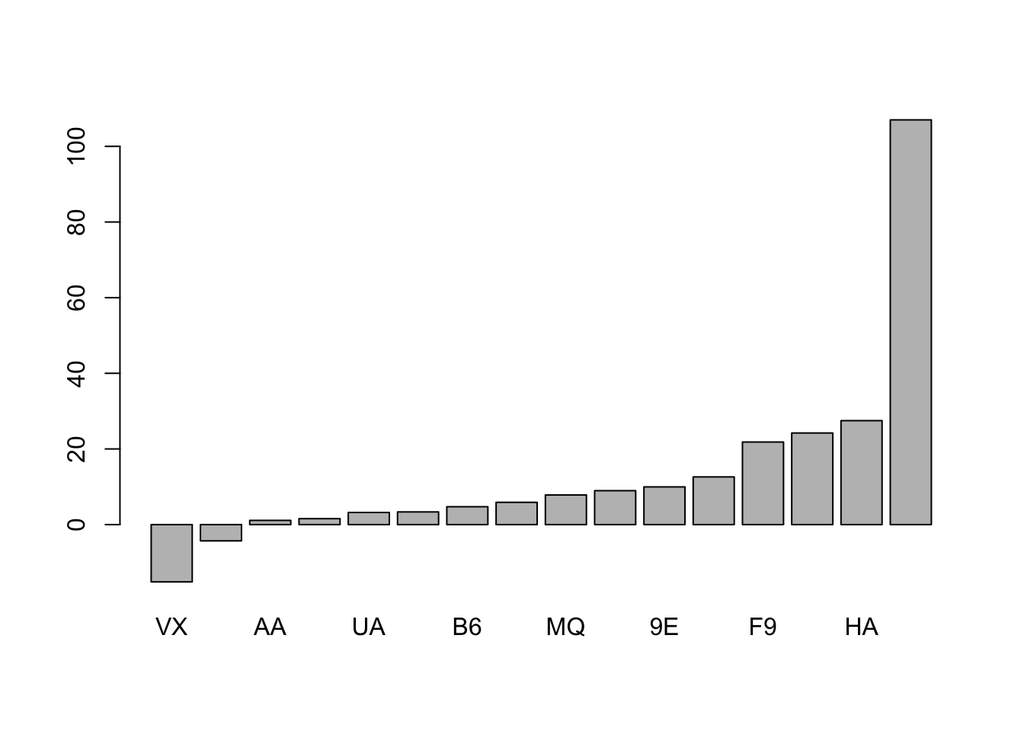

```r
barplot(sort(tapply(flights$arr_delay, flights$carrier, mean)))
```

### Conditionals, Logical Indexing, and If-Else Statements

Sometimes we want to explore data based on criteria other than the factors we have available. This where conditionals, Booleans, and logical indexing come in handy.

#### Booleans and Conditonals

A Boolean is a binary type of data that takes on either `TRUE` or `FALSE`. Sometimes you will also see 1 and 0 representing true and false values, respectively. In R, Boolean types are called `logical`.

```r
typeof(TRUE)
```

```
## [1] "logical"
```

A conditional statement is a statement that evaluates to a Boolean value. We use them to make decisions. If the condition is true, do one thing, otherwise do the other thing. We make conditions by using comparison operators:

- `==` equal
- `!=` not equal
- `>` greater than
- `<` less than
- `>=` greater than or equal to
- `<=` less than or equal to

```r
# can compare ints and other numericals
5 == 5.0
```

```
## [1] TRUE
```

```r
6 > 99
```

```
## [1] FALSE
```

```r
# camparing strings
'hello' == "hello"
```

```
## [1] TRUE
```

```r
# compare lexicographical order, i.e., alphabetical with numbers and symbols
'abc' < 'dfg'
```

```
## [1] TRUE
```

```r
# can check a factor level with a string of the matching name
as.factor('level1') == 'level1'
```

```
## [1] TRUE
```

We can than use logical operators to combine conditionals:

Elementwise

- `&` and, TRUE if both elements are true
- `|` or, TRUE if at least one element is true
- `!` not, TRUE if the element is false

Statementwise

- `&&` and, TRUE if both statement are true
- `||` or, TRUE if at least one statement is true
- `!` not, TRUE if the statement is false

```r
TRUE && FALSE
```

```
## [1] FALSE
```

```r
5 >= 0 || 'this' == 'that'
```

```
## [1] TRUE
```

You want to use elementwise operators when dealing with vectors.

```r
nums1 <- c(1, 2, 3, 4, 5, 6, 7, 8, 9, 10)

nums1 == 4 | nums1 >= 7
```

```
##  [1] FALSE FALSE FALSE  TRUE FALSE FALSE  TRUE  TRUE  TRUE  TRUE
```

```r
# %% is the modulus operator, i.e., remainder division
nums1 > 5 & nums1 %% 2 == 0
```

```
##  [1] FALSE FALSE FALSE FALSE FALSE  TRUE FALSE  TRUE FALSE  TRUE
```

```r
nums2 <- c(1, 2, 33, 44, 5, 6, 77, 8, 99, 10)

nums1 == nums2
```

```
##  [1]  TRUE  TRUE FALSE FALSE  TRUE  TRUE FALSE  TRUE FALSE  TRUE
```

```r
nums1 < nums2
```

```
##  [1] FALSE FALSE  TRUE  TRUE FALSE FALSE  TRUE FALSE  TRUE FALSE
```

#### Logical Indexing

Sometimes you want a subset of your data based on a set of rules. This is where we would use logical indexing. It is similar to regular indexing, but instead of numerical indexes, we pass a conditional. R will then evaluate that condition on each row and select the ones where it returns true. Because we are selecting rows, remember to use the trailing comma.

```r
flights[flights$origin == 'JFK', ]
```

```
##   day dep_time dep_delay arr_time arr_delay carrier tailnum flight origin dest
## 3   1      542         2      923        33      AA  N619AA   1141    JFK  MIA
## 4   1      544        -1     1004       -18      B6  N804JB    725    JFK  BQN
## 9   1      557        -3      838        -8      B6  N593JB     79    JFK  MCO
##   air_time distance hour minute
## 3      160     1089    5     42
## 4      183     1576    5     44
## 9      140      944    5     57
##  [ reached 'max' / getOption("max.print") -- omitted 9158 rows ]
```

```r
flights[flights$origin == 'JFK' & flights$day == 17, ]
```

```
##       day dep_time dep_delay arr_time arr_delay carrier tailnum flight origin
## 14007  17      537        -3     1023         6      B6  N579JB    725    JFK
## 14008  17      544         4      845        -5      AA  N628AA   1141    JFK
## 14013  17      553        -7      904        -8      B6  N527JB    135    JFK
##       dest air_time distance hour minute
## 14007  BQN      206     1576    5     37
## 14008  MIA      157     1089    5     44
## 14013  RSW      168     1074    5     53
##  [ reached 'max' / getOption("max.print") -- omitted 299 rows ]
```

We can combine logical indexing with selecting a specific column or columns.

```r
flights[flights$origin == 'JFK' & flights$day == 17, 'arr_delay']
```

```
##  [1]   6  -5  -8  -7  20  -1  10   4  -2  -4  11   7   8 -15 -13  -4  -9  -4 -16
## [20] -11 -20  -6 -14  -5 -18 -23  10 -17   2 -13  30  -5 -10  -7  10 -22 -10  14
## [39] -21  12  -1   7  -5 -18  -3 -12   6   1  52   9
##  [ reached getOption("max.print") -- omitted 252 entries ]
```

```r
flights[flights$origin == 'JFK' & flights$day == 17, ]$arr_delay
```

```
##  [1]   6  -5  -8  -7  20  -1  10   4  -2  -4  11   7   8 -15 -13  -4  -9  -4 -16
## [20] -11 -20  -6 -14  -5 -18 -23  10 -17   2 -13  30  -5 -10  -7  10 -22 -10  14
## [39] -21  12  -1   7  -5 -18  -3 -12   6   1  52   9
##  [ reached getOption("max.print") -- omitted 252 entries ]
```

```r
flights[flights$origin == 'JFK' & flights$day == 17, c('dest', 'arr_delay', 'dep_delay')]
```

```
##       dest arr_delay dep_delay
## 14007  BQN         6        -3
## 14008  MIA        -5         4
## 14013  RSW        -8        -7
## 14017  IAD        -7        -3
## 14024  SFO        20         1
## 14025  PHL        -1         2
## 14026  LAX        10         1
## 14030  SJU         4        -6
## 14034  FLL        -2         9
## 14037  PBI        -4         0
## 14038  ATL        11        -3
## 14039  CLT         7        -2
## 14044  ORD         8        -7
## 14048  BOS       -15        -6
## 14049  MCO       -13         0
## 14052  TPA        -4        -2
##  [ reached 'max' / getOption("max.print") -- omitted 286 rows ]
```

#### If-Else

Another use of conditionals is If-Else statement. There are two types of if-else statements in R. The first is an if block. We use this when our code needs to take a different set of actions depending on input. These diferent sets of actions are called branches.

```r
input <- 42

if (input == 42) {
    'the answer to life'
} else {
    'doesn\'t mean anything'
}
```

```
## [1] "the answer to life"
```

We also can use the `ifelse` function to return a value depending on the input. This is useful when updating columns or creating new ones, like we saw above with data cleaning.

To create a new column, specify a column like usual, but with a column name that doesn’t exist yet, and assign value to it: `df$<new column name> <- <values>`.

We use `ifelse` like so: `ifelse(<test>, <value if true>, <value if false>)`. You can also nest `ifelse` statements.

```r
flights$late <- ifelse(flights$arr_delay > 0, TRUE, FALSE)

flights$arr_type <- ifelse(flights$arr_delay < 0,           # the first test
                           'early',                         # value if the first test is true
                           ifelse(flights$arr_delay == 0,   # the second test, checked when the first is false
                                  'on time',                # value if the second test if true and the first is false
                                  'late'                    # value if both tests are false
                                  )
                           )
```

## Random Sampling and Testing

When we create models, we want to be able to test them. We need to know if our models are valid or good at predicting. We do this by splitting off a portion of our data for testing. We use one set to train the models, predict the other set, and then compare the predicted value to the true value.

Sometimes our data comes in ordered, so we want to make sure the data in our test set is a random selection. To do this, we use `sample`. This function returns a specified amount of random numbers within a specified range. We use it like so: `sample(<start of range>:<end of range>, <how many numbers we want>)`. For test sets, the start is 1 and the end is the number of rows. The amount can fluctuate, but 10-30% of your data is typically a good amount. You want to make sure there is enough data in your test set to properly evaluate your model.

The output of `sample` is a set of numbers. We will use those numbers as the set of indices to be in out test set. So, we will tell R to put all rows with any of those indices in a test set and every row not in there will be in our train set.

**Tip** Use `set.seed` to set the random seed of R’s random number generator. This will make reruns of your random functions deterministic, i.e., have the same output each run. Set the seed again when you want to rerun any random based functions to get the same result, even across machines, typically.

```r
set.seed(12345)

# get a random set of numbers from 1 to the number of rows in out data, we want 20% of the rows
test_indices <- sample(1:nrow(flights), 0.2 * nrow(flights))

# our test set should consist of all the rows with indices from the sample function
test_set <- flights[test_indices, ]
# our train set is anything but those indices
train_set <- flights[-test_indices, ]
```

We can then move on with creating our models from the train set and then evaluate them with the test set.